# Spatial-Mode Workflow: Visium Data

2026-06-11

## Overview

In spatially resolved transcriptomics, the physical positions of cells or spots are not incidental — they are biological information. Cells that are physically adjacent share a local microenvironment, exchange secreted molecules, and respond to the same spatial cues. Defining signaling neighborhoods by proximity is therefore more principled than random pairing.

NICHESv2’s **spatial mode** uses the coordinates in your data to construct a neighbor graph, then scores ligand–receptor-mediated (LRM) signaling along every edge of that graph. Two parameter paths are available:

- **kNN** (`k`): each spot is connected to its *k* nearest neighbors by Euclidean distance. Simple and dataset-agnostic.
- **Radius** (`rad`): each spot is connected to all spots within a fixed physical radius. More interpretable when the coordinate units have a known biological meaning (e.g. micrometres in Visium).

This vignette demonstrates the spatial-mode workflow using the [`stxBrain`](https://github.com/satijalab/seurat-data) dataset: ~2,700 Visium spots from the mouse brain anterior section, with strong spatial tissue organisation that makes signaling patterns immediately interpretable.

## Setup

```r
library(NICHESv2)
library(SeuratData)   # github.com/satijalab/seurat-data
library(SeuratObject)
```

Install and load the `stxBrain` dataset if you have not done so already:

```r
# Run once to download (~150 MB)
# SeuratData::InstallData("stxBrain")

data("anterior1")
anterior1 <- UpdateSeuratObject(anterior1)
```

```
#> Validating object structure
#> Updating object slots
#> Ensuring keys are in the proper structure
#> Ensuring keys are in the proper structure
#> Ensuring feature names don't have underscores or pipes
#> Updating slots in Spatial
#> Updating slots in anterior1
#> Validating object structure for Assay5 'Spatial'
#> Validating object structure for VisiumV2 'anterior1'
#> Object representation is consistent with the most current Seurat version
```

```r
anterior1
```

```
#> An object of class Seurat
#> 31053 features across 2696 samples within 1 assay
#> Active assay: Spatial (31053 features, 0 variable features)
#>  1 layer present: counts
#>  1 spatial field of view present: anterior1
#> An object of class Seurat
#> 31053 features across 2696 samples within 1 assay
#> Active assay: Spatial (31053 features, 0 variable features)
#>  1 layer present: counts
#>  1 spatial field of view present: anterior1
```

## Step 1 — Ingest from Seurat

```r
inputs.stx <- extract_NICHESInputs_Seurat(
  seurat.obj = anterior1,
  assay      = "Spatial",
  layer      = "counts",
  verbose    = TRUE
)
```

```
#> [NICHESv2] Extracted 31053 genes x 2696 cells from assay 'Spatial', layer 'counts' (V5 Assay5).
#> [NICHESv2] Cell metadata: 5 column(s): orig.ident, nCount_Spatial, nFeature_Spatial, slice, region
#> [NICHESv2] NOTE: For spatial mode, create_NICHESObject() requires
#>   columns named 'x' and 'y' in meta.data. If your spatial coordinates
#>   are stored in seurat.obj@images, extract them with:
#>     coords <- SeuratObject::GetTissueCoordinates(seurat.obj)
#>   then add them to inputs$meta.data before calling create_NICHESObject().
```

```r
dim(inputs.stx$count.mtx)
```

```
#> [1] 31053  2696
#> [1] 31053  2696       # genes × spots
```

```r
colnames(inputs.stx$meta.data)
```

```
#> [1] "orig.ident"       "nCount_Spatial"   "nFeature_Spatial" "slice"
#> [5] "region"
#> [1] "orig.ident"       "nCount_Spatial"   "nFeature_Spatial"
#> [4] "slice"            "region"
```

### Extracting spatial coordinates

Unlike Seurat objects with dimensionality reduction embeddings, Visium objects store spatial coordinates in the image slot rather than in cell metadata. `extract_NICHESInputs_Seurat()` does not automatically transfer them, so we do this manually before calling `create_NICHESObject()`.

For `VisiumV2` objects (Seurat ≥ 5), coordinates live in `@images[[i]]@boundaries$centroids`:

```r
# Retrieve barcodes and coordinates from the VisiumV2 image slot
barcodes <- anterior1@images$anterior1@boundaries$centroids@cells
coords   <- anterior1@images$anterior1@boundaries$centroids@coords
rownames(coords) <- barcodes

# Safety check: all barcodes present in meta.data
all(barcodes %in% rownames(inputs.stx$meta.data))
```

```
#> [1] TRUE
#> [1] TRUE
```

```r
sum(is.na(coords[rownames(inputs.stx$meta.data), "x"]))
```

```
#> [1] 0
#> [1] 0
```

```r
# Join coordinates into meta.data by barcode name (safe, not positional)
inputs.stx$meta.data$x <- coords[rownames(inputs.stx$meta.data), "x"]
inputs.stx$meta.data$y <- coords[rownames(inputs.stx$meta.data), "y"]

head(inputs.stx$meta.data[, c("x", "y")], 3)
```

```
#>                       x    y
#> AAACAAGTATCTCCCA-1 7475 8501
#> AAACACCAATAACTGC-1 8553 2788
#> AAACAGAGCGACTCCT-1 3164 7950
#>                       x    y
#> AAACAAGTATCTCCCA-1 7475 8501
#> AAACACCAATAACTGC-1 8553 2788
#> AAACAGAGCGACTCCT-1 3164 7950
```

## Step 2 — Choosing a neighborhood radius

NICHESv2 provides `Explore_Radius_Neighborhood()` to help you relate a physical radius value to the expected number of neighbors per spot, **before** you commit to building the full object. This is useful because the right radius depends on your tissue’s spot density and coordinate units, which vary across platforms and experiments.

The function samples a subset of spots, counts neighbors at each radius step, and returns a plot of mean neighbor count vs. radius:

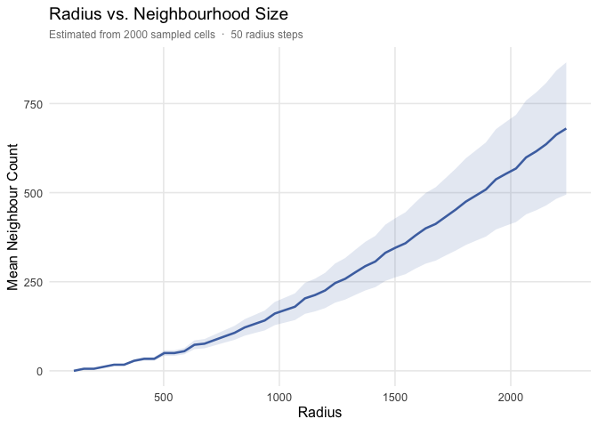

```r
coords.df <- data.frame(
  x = inputs.stx$meta.data$x,
  y = inputs.stx$meta.data$y
)

# Full range — get an overview first
Explore_Radius_Neighborhood(coords.df)
```

The full-range plot shows that large radii (>1000) produce hundreds of neighbors per spot — biologically implausible and computationally expensive. Zoom into the actionable range by setting `r.max`:

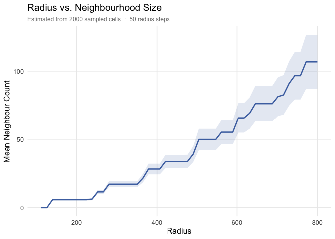

```r
# Zoom into the actionable range
Explore_Radius_Neighborhood(coords.df, r.max = 800)
```

The staircase shape is a feature of the Visium hexagonal grid: spots are arranged in concentric hexagonal rings, so neighbor count increases in discrete jumps rather than smoothly. Reading the zoomed plot:

- **Radius ~200** → ~6 neighbors per spot (equivalent to the first hexagonal ring)
- **Radius ~400** → ~25–30 neighbors (two rings)
- **Radius ~600** → ~50–60 neighbors (three rings)

For a first analysis, **6 immediate neighbors** is a natural starting point — it captures direct physical contacts without diluting the signal with distal spots. In this vignette we use `k = 6` (kNN mode) for simplicity and reproducibility, which is equivalent to radius ~200 for this dataset:

```r
# Note on sample splitting:
# This dataset contains a single tissue section, so sample.col = NULL.
# If your experiment includes multiple sections or capture areas, always
# set sample.col to avoid edges being constructed across sections.
```

## Step 3 — Build the NICHESObject

```r
niches.stx <- create_NICHESObject(
  count.mtx  = inputs.stx$count.mtx,
  meta.data  = inputs.stx$meta.data,
  LRM.db     = load_LRM_database("fantom5", species = "mouse"),
  mode       = "spatial",
  species    = "mouse",
  sample.col = NULL,
  k          = 6L,
  method     = "product",
  n.cores    = 4L,
  verbose    = TRUE
)
```

`load_LRM_database("fantom5", species = "mouse")` loads the bundled FANTOM5 ligand–receptor database for mouse — no internet connection required.

## Step 4 — Inspect the result

```r
print(niches.stx)
```

```
#> -- NICHESObject --------------------------------------------
#>   Cells        : 2696  (2696 non-empty)
#>   Genes        : 31053  (20467 valid)
#>   Edges        : 18500  (18495 non-empty)
#>   LRM pairs    : 2251  (1827 valid)
#>   Segmentation : none
#>
#>   Slot summary:
#>     $cell.list     -- character vector of cell barcodes
#>     $cell.data     -- (cell, gene, score, score.norm) [sparse]
#>     $cell.meta     -- per-cell metadata
#>     $edge.list     -- (edge, SendingCell, ReceivingCell)
#>     $edge.data     -- (edge, LRM, score, score.norm) [sparse]
#>     $edge.meta     -- per-edge metadata with Sending/Receiving/Joint cols
#>     $neighborhood.* -- reserved (NULL)
#>     $gene.list     -- character vector of gene names
#>     $gene.meta     -- per-gene metadata
#>     $LRM.list      -- character vector of 'ligand|receptor' pairs
#>     $LRM.meta      -- per-LRM metadata
#>     $segmentation  -- sf object of cell polygons, or NULL
#> ------------------------------------------------------------
```

In spatial mode, `$edge.data` carries the same `edge | LRM | score | score.norm` structure as sampled mode, but each edge now corresponds to a physically proximal spot pair. The sending spot’s coordinates are stored in `$edge.meta`:

```r
head(niches.stx$edge.data, 3)
```

```
#> Key: <edge, LRM>
#>                                          edge          LRM score  score.norm
#>                                        <char>       <char> <num>       <num>
#> 1: AAACAAGTATCTCCCA-1|AAACAAGTATCTCCCA-1 Adam15|Itgav     4 0.003798670
#> 2: AAACAAGTATCTCCCA-1|AAACAAGTATCTCCCA-1    Apoe|Lrp1   148 0.140550810
#> 3: AAACAAGTATCTCCCA-1|AAACAAGTATCTCCCA-1   Apoe|Sorl1    37 0.035137700
```